# St. Martins Marsh Aquatic Preserve

SEACAR Water Quality Analysis

Last compiled on 15 July, 2026

# Indicators

## Nutrients

### Total Nitrogen - Discrete

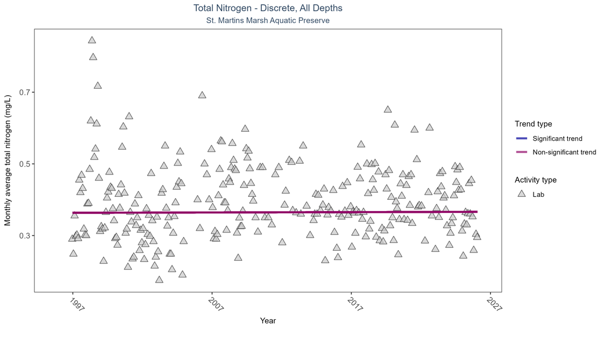

Scatter plot of monthly average total nitrogen over time. If the time series included ten or more years of discrete observations, a significant (blue) or non-significant (magenta) trend line is also shown. Only nitrogen values obtained from laboratory analyses (triangles) are included in the plot.

Table:

Total nitrogen showed no detectable trend between 1996 and 2026.

| Activity Type | Statistical Trend | Sample Count | Years with Data | Period of Record | Median Result Value | Tau | Sen Intercept | Sen Slope | P |
| --- | --- | --- | --- | --- | --- | --- | --- | --- | --- |
| Lab | No detectable trend | 1545 | 31 | 1996 - 2026 | 0.36 | 0.02489 | 0.36348 | 0.00009 | 0.8414 |

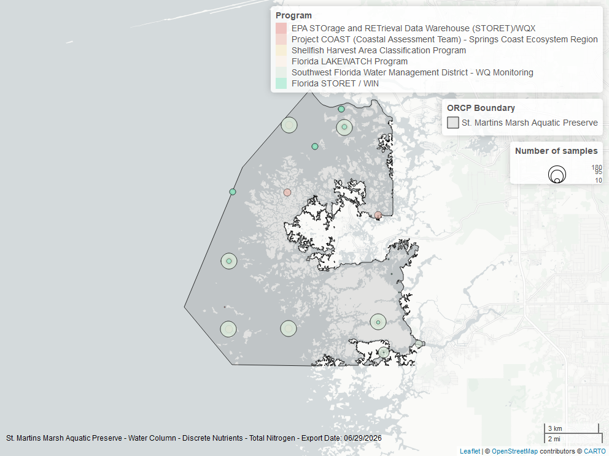

Map showing location of discrete water quality sampling locations within the boundaries of *St. Martins Marsh Aquatic Preserve*. The bubble size on the maps above reflect the amount of data available at each sampling site.

### Total Phosphorus - Discrete

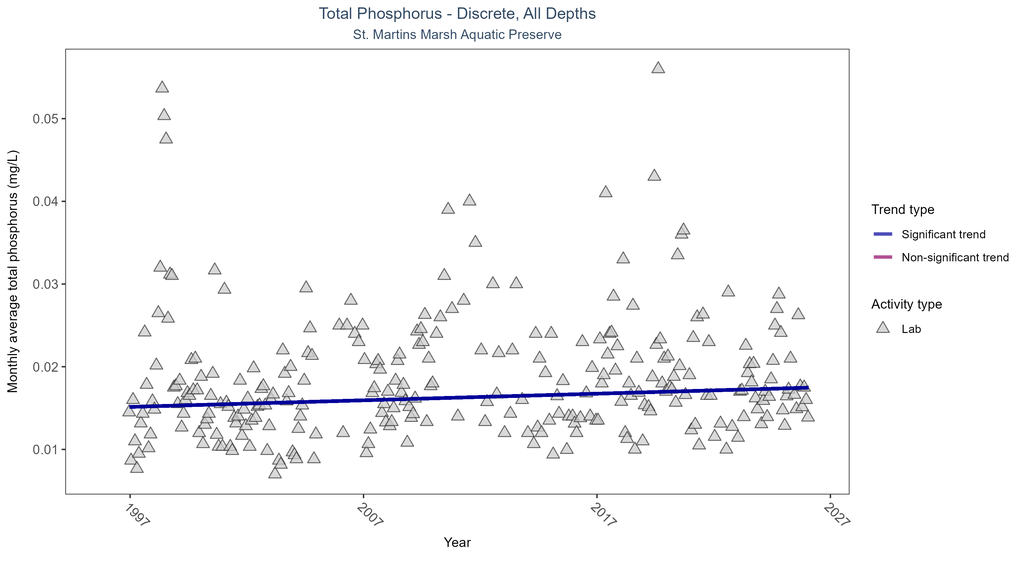

Scatter plot of monthly average total phosphorus over time. If the time series included ten or more years of discrete observations, a significant (blue) or non-significant (magenta) trend line is also shown. Only phosphorus values obtained from laboratory analyses (triangles) are included in the plot.

Table:

Monthly average total phosphorus increased by less than 0.01 mg/L per year.

| Activity Type | Statistical Trend | Sample Count | Years with Data | Period of Record | Median Result Value | Tau | Sen Intercept | Sen Slope | P |
| --- | --- | --- | --- | --- | --- | --- | --- | --- | --- |
| Lab | Increasing trend | 1542 | 31 | 1996 - 2026 | 0.015 | 0.10625 | 0.01506 | 0.00008 | 0.0349 |

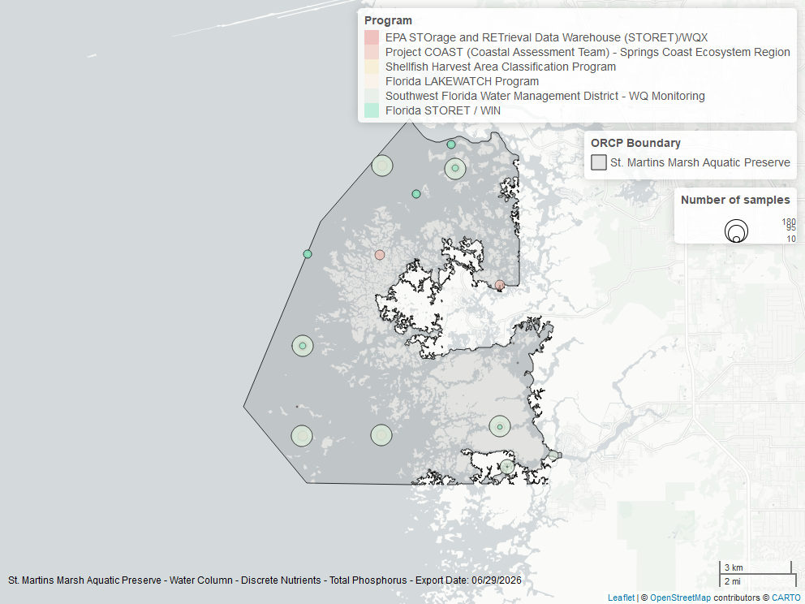

Map showing location of discrete water quality sampling locations within the boundaries of *St. Martins Marsh Aquatic Preserve*. The bubble size on the maps above reflect the amount of data available at each sampling site.

## Water Quality

### Dissolved Oxygen - Continuous

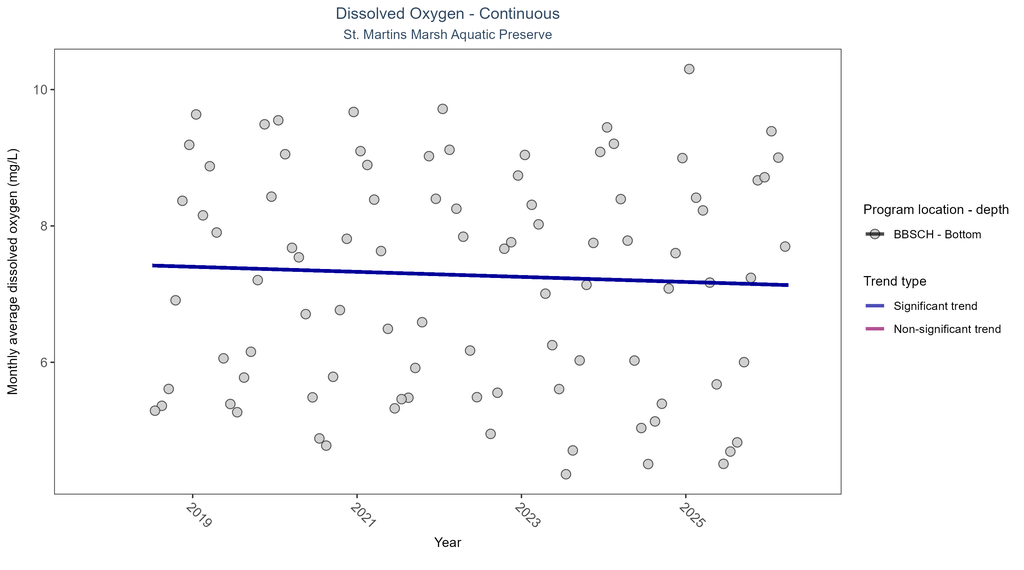

Scatter plot of monthly average dissolved oxygen over time at continuously monitored program locations. Each location is analyzed separately, with significant (blue) or non-significant (magenta) trend lines shown for time series that included five or more years of observations.

Table:

At one program location, monthly average dissolved oxygen decreased by 0.04 mg/L per year.

| Program Location | Statistical Trend | Sample Count | Years with Data | Period of Record | Median Result Value | Tau | Sen Intercept | Sen Slope | P |
| --- | --- | --- | --- | --- | --- | --- | --- | --- | --- |
| BBSCH | Decreasing trend | 243248 | 9 | 2018 - 2026 | 7.4 | -0.2 | 7.44 | -0.04 | 0.03 |

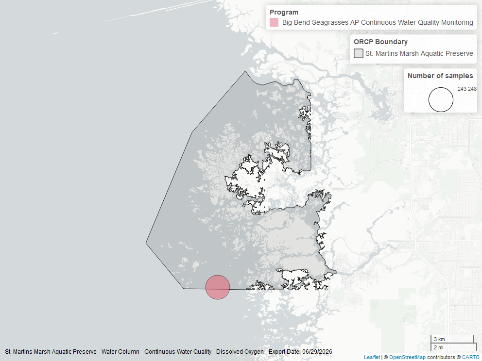

Map showing location of dissolved oxygen continuous water quality sampling locations within the boundaries of *St. Martins Marsh Aquatic Preserve*. The bubble size on the maps above reflect the amount of data available at each sampling site.

### Dissolved Oxygen - Discrete

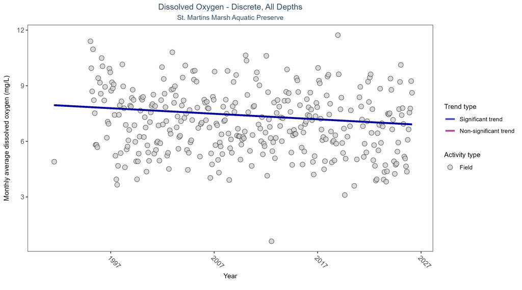

Scatter plot of monthly average dissolved oxygen over time. If the time series included ten or more years of discrete observations, a significant (blue) or non-significant (magenta) trend line is also shown. Only dissolved oxygen values measured in the field (circles) are included in the plot.

Table:

Monthly average dissolved oxygen decreased by 0.03 mg/L per year.

| Activity Type | Statistical Trend | Sample Count | Years with Data | Period of Record | Median Result Value | Tau | Sen Intercept | Sen Slope | P |
| --- | --- | --- | --- | --- | --- | --- | --- | --- | --- |
| Field | Decreasing trend | 8740 | 33 | 1991 - 2026 | 7.275 | -0.1597 | 7.96651 | -0.02991 | 0 |

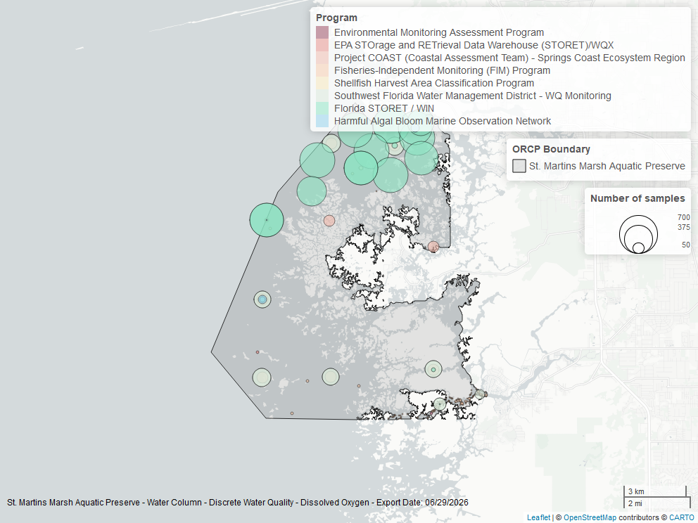

Map showing location of discrete water quality sampling locations within the boundaries of *St. Martins Marsh Aquatic Preserve*. The bubble size on the maps above reflect the amount of data available at each sampling site.

### Dissolved Oxygen Saturation - Continuous

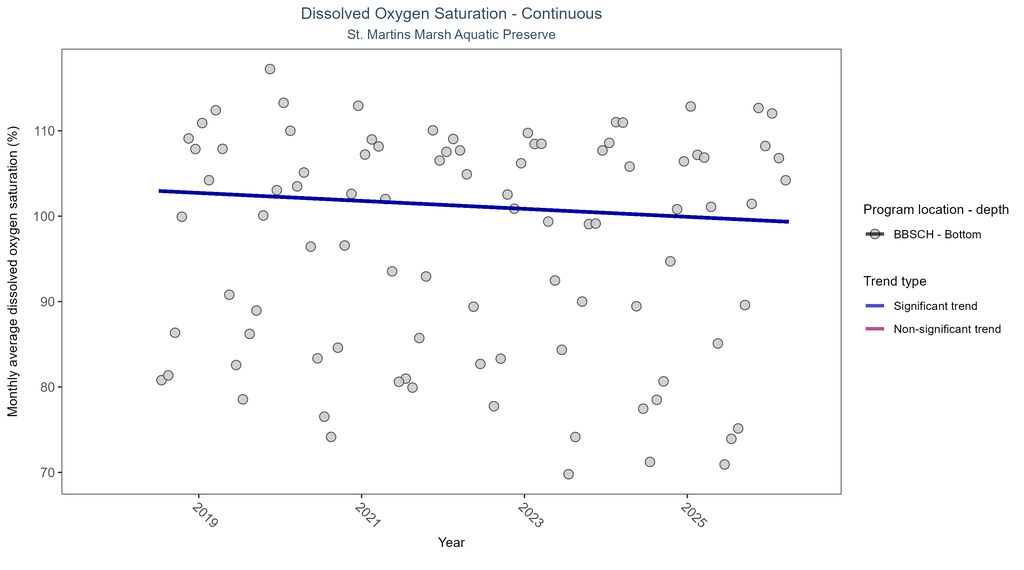

Scatter plot of monthly average dissolved oxygen saturation over time at continuously monitored program locations. Each location is analyzed separately, with significant (blue) or non-significant (magenta) trend lines shown for time series that included five or more years of observations.

Table:

At one program location, monthly average dissolved oxygen saturation decreased by 0.47% per year.

| Program Location | Statistical Trend | Sample Count | Years with Data | Period of Record | Median Result Value | Tau | Sen Intercept | Sen Slope | P |
| --- | --- | --- | --- | --- | --- | --- | --- | --- | --- |
| BBSCH | Decreasing trend | 241140 | 9 | 2018 - 2026 | 98.4 | -0.21 | 103.19 | -0.47 | 0.02 |

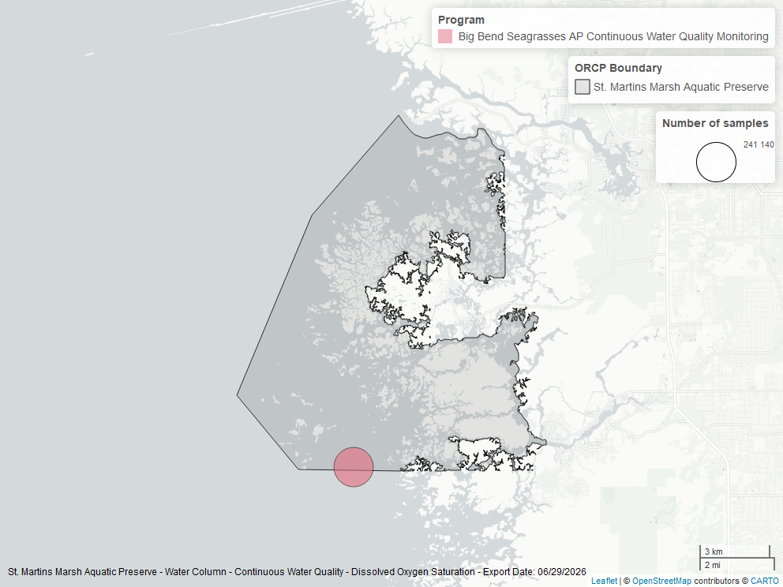

Map showing location of dissolved oxygen saturation continuous water quality sampling locations within the boundaries of *St. Martins Marsh Aquatic Preserve*. The bubble size on the maps above reflect the amount of data available at each sampling site.

### Dissolved Oxygen Saturation - Discrete

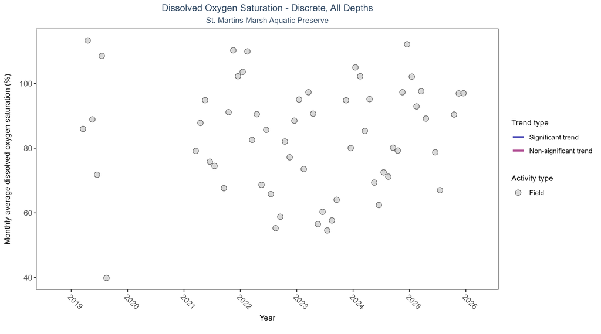

Scatter plot of monthly average dissolved oxygen saturation over time. If the time series included ten or more years of discrete observations, a significant (blue) or non-significant (magenta) trend line is also shown. Only dissolved oxygen saturation values measured in the field (circles) are included in the plot.

Table:

There was insufficient data to fit a model for dissolved oxygen saturation.

| Activity Type | Statistical Trend | Sample Count | Years with Data | Period of Record | Median Result Value | Tau | Sen Intercept | Sen Slope | P |
| --- | --- | --- | --- | --- | --- | --- | --- | --- | --- |
| Field | Insufficient data | 462 | 6 | 2019 - 2025 | 86.5 | - | - | - | - |

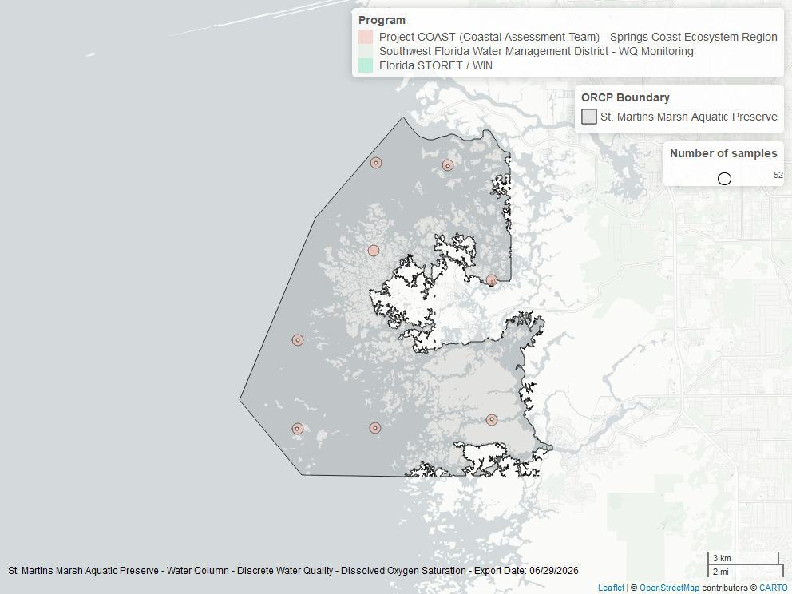

Map showing location of discrete water quality sampling locations within the boundaries of *St. Martins Marsh Aquatic Preserve*. The bubble size on the maps above reflect the amount of data available at each sampling site.

### Salinity - Discrete

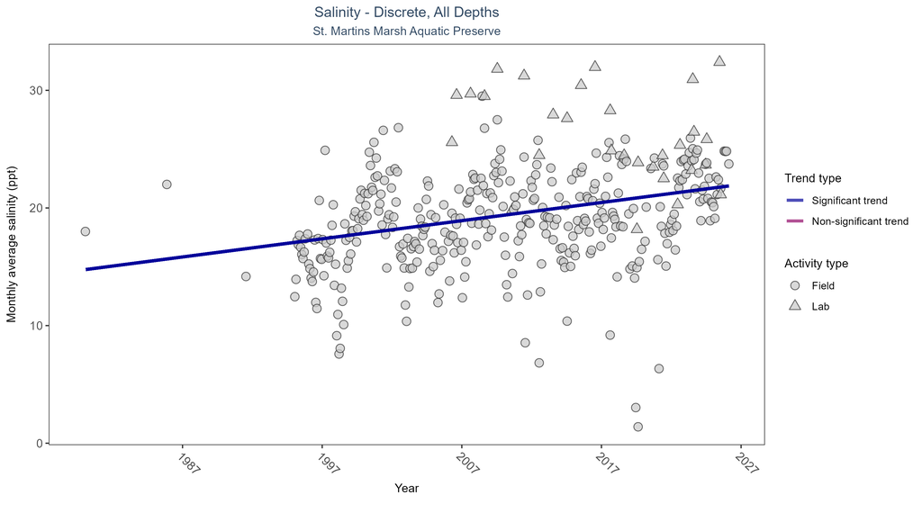

Scatter plot of monthly average salinity over time. If the time series included ten or more years of discrete observations, significant (blue) or non-significant (magenta) trend lines are also shown. Discrete salinity values derived from grab samples analyzed in the field (circles) or the laboratory (triangles) are both included in the plot.

Table:

Monthly average salinity increased by 0.15 ppt per year.

| Activity Type | Statistical Trend | Sample Count | Years with Data | Period of Record | Median Result Value | Tau | Sen Intercept | Sen Slope | P |
| --- | --- | --- | --- | --- | --- | --- | --- | --- | --- |
| All | Increasing trend | 9681 | 35 | 1980 - 2026 | 18.4 | 0.26806 | 14.75431 | 0.15428 | 0 |

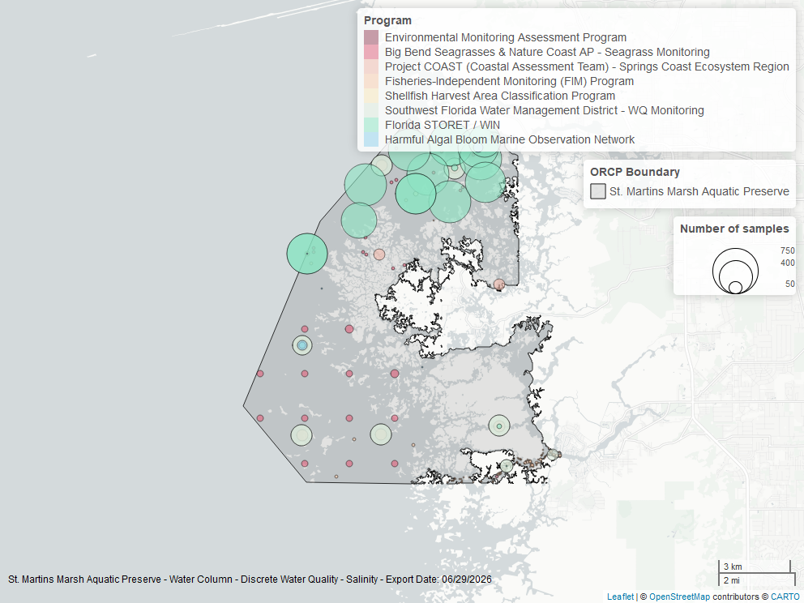

Map showing location of discrete water quality sampling locations within the boundaries of *St. Martins Marsh Aquatic Preserve*. The bubble size on the maps above reflect the amount of data available at each sampling site.

### Salinity - Continuous

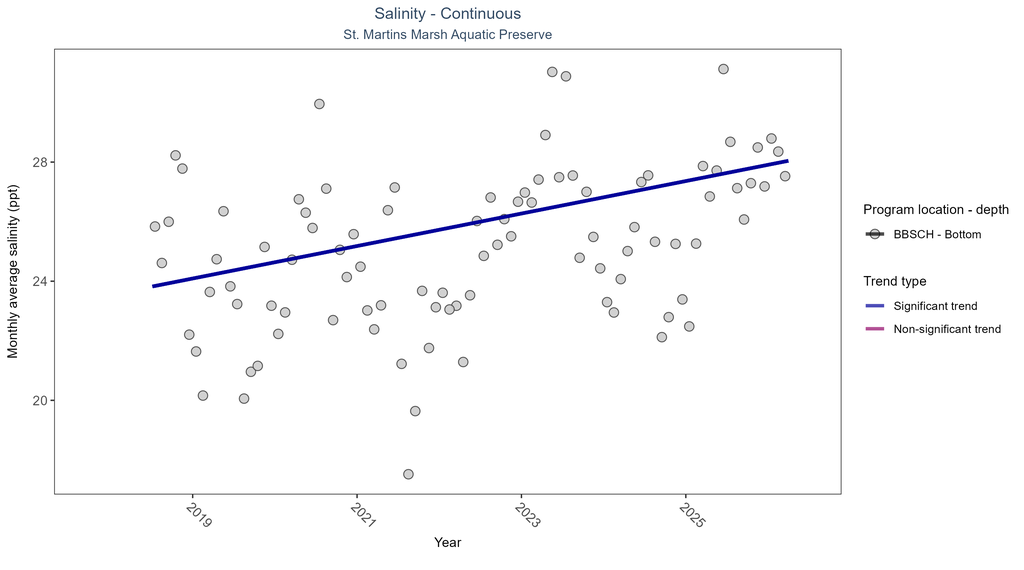

Scatter plot of monthly average salinity over time at continuously monitored program locations. Each location is analyzed separately, with significant (blue) or non-significant (magenta) trend lines shown for time series that included five or more years of observations.

Table:

At one program location, monthly average salinity increased by 0.55 ppt per year.

| Program Location | Statistical Trend | Sample Count | Years with Data | Period of Record | Median Result Value | Tau | Sen Intercept | Sen Slope | P |
| --- | --- | --- | --- | --- | --- | --- | --- | --- | --- |
| BBSCH | Increasing trend | 251661 | 9 | 2018 - 2026 | 25.4 | 0.36 | 23.55 | 0.55 | 0 |

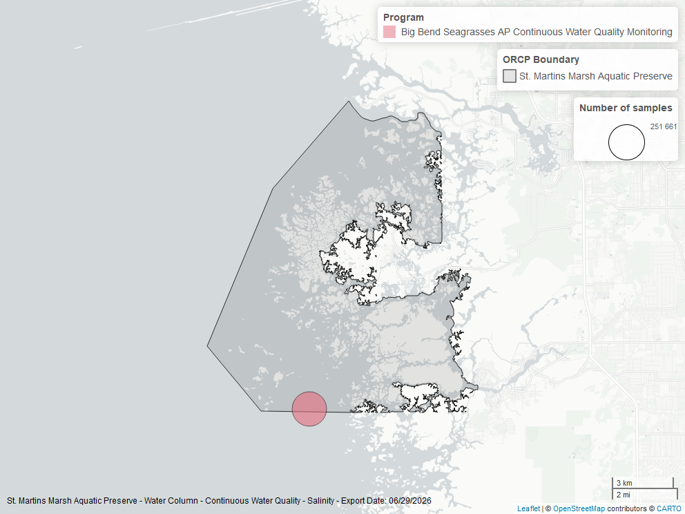

Map showing location of salinity continuous water quality sampling locations within the boundaries of *St. Martins Marsh Aquatic Preserve*. The bubble size on the maps above reflect the amount of data available at each sampling site.

### Water Temperature - Continuous

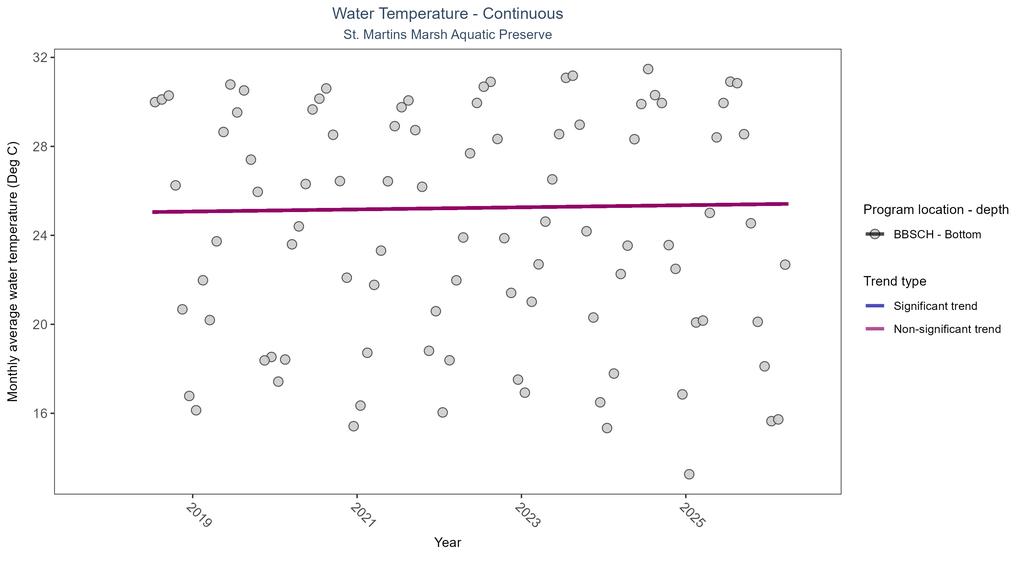

Scatter plot of monthly average water temperature over time at continuously monitored program locations. Each location is analyzed separately, with significant (blue) or non-significant (magenta) trend lines shown for time series that included five or more years of observations.

Table:

No detectable change in monthly average water temperature was observed at one location.

| Program Location | Statistical Trend | Sample Count | Years with Data | Period of Record | Median Result Value | Tau | Sen Intercept | Sen Slope | P |
| --- | --- | --- | --- | --- | --- | --- | --- | --- | --- |
| BBSCH | No detectable trend | 253721 | 9 | 2018 - 2026 | 24.7 | 0.04 | 25.02 | 0.05 | 0.71 |

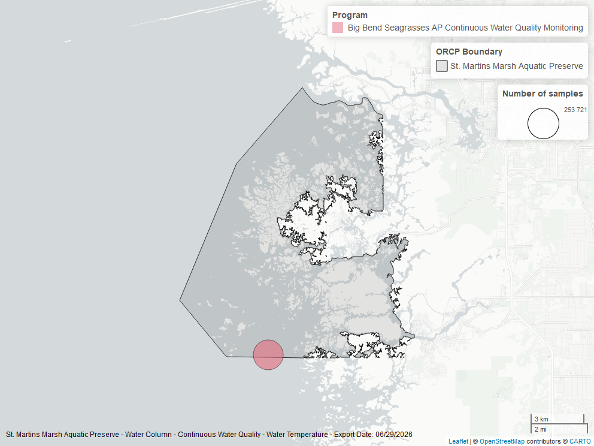

Map showing location of water temperature continuous water quality sampling locations within the boundaries of *St. Martins Marsh Aquatic Preserve*. The bubble size on the maps above reflect the amount of data available at each sampling site.

### Water Temperature - Discrete

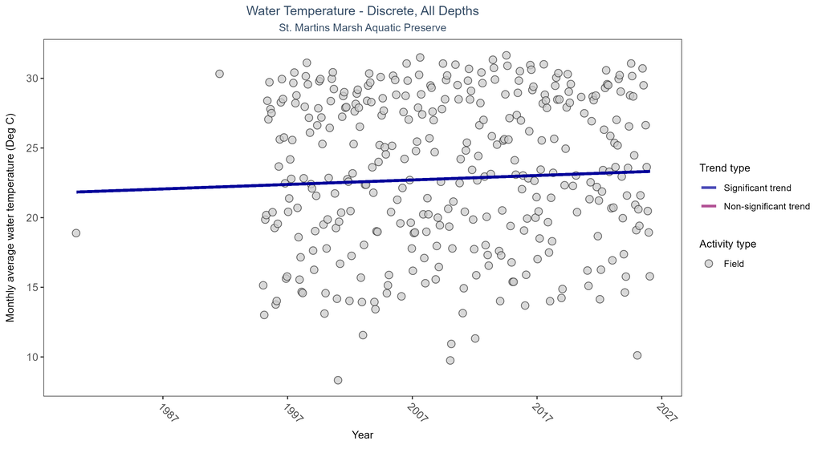

Scatter plot of monthly average water temperature over time. If the time series included ten or more years of discrete observations, a significant (blue) or non-significant (magenta) trend line is also shown. Only water temperature measurements taken in the field (circles) are included in the plot.

Table:

Monthly average water temperature increased by 0.03°C per year.

| Activity Type | Statistical Trend | Sample Count | Years with Data | Period of Record | Median Result Value | Tau | Sen Intercept | Sen Slope | P |
| --- | --- | --- | --- | --- | --- | --- | --- | --- | --- |
| Field | Increasing trend | 9166 | 34 | 1980 - 2026 | 22.7 | 0.12239 | 21.83555 | 0.03218 | 0.0017 |

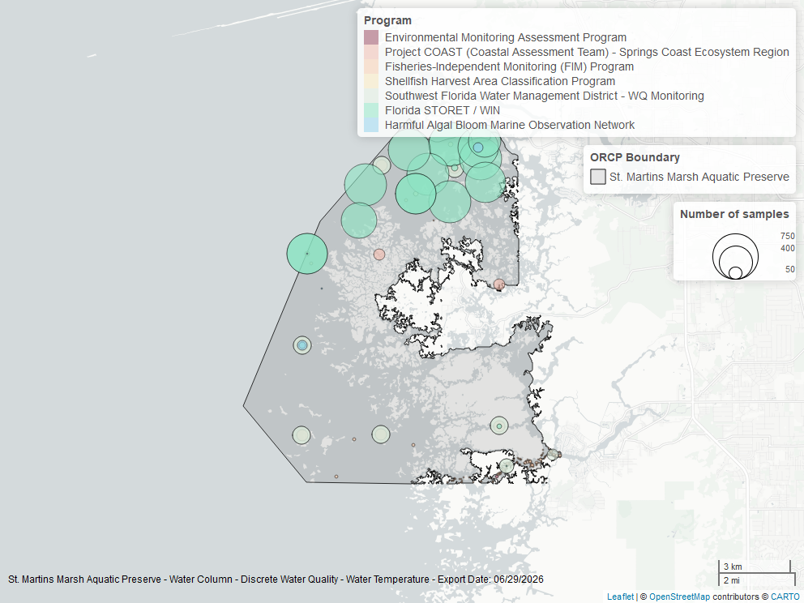

Map showing location of discrete water quality sampling locations within the boundaries of *St. Martins Marsh Aquatic Preserve*. The bubble size on the maps above reflect the amount of data available at each sampling site.

### pH - Continuous

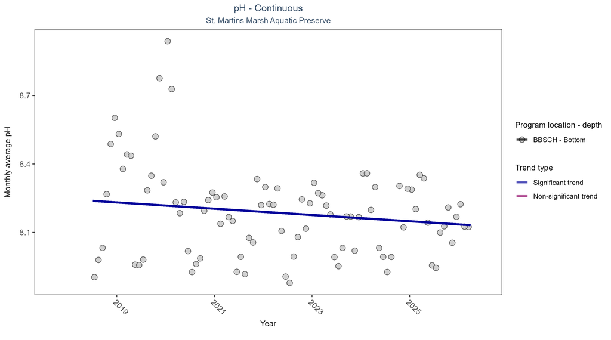

Scatter plot of monthly average pH over time at continuously monitored program locations. Each location is analyzed separately, with significant (blue) or non-significant (magenta) trend lines shown for time series that included five or more years of observations.

Table:

At one program location, monthly average pH decreased by 0.01 pH units per year.

| Program Location | Statistical Trend | Sample Count | Years with Data | Period of Record | Median Result Value | Tau | Sen Intercept | Sen Slope | P |
| --- | --- | --- | --- | --- | --- | --- | --- | --- | --- |
| BBSCH | Decreasing trend | 245245 | 9 | 2018 - 2026 | 8.2 | -0.16 | 8.25 | -0.01 | 0.05 |

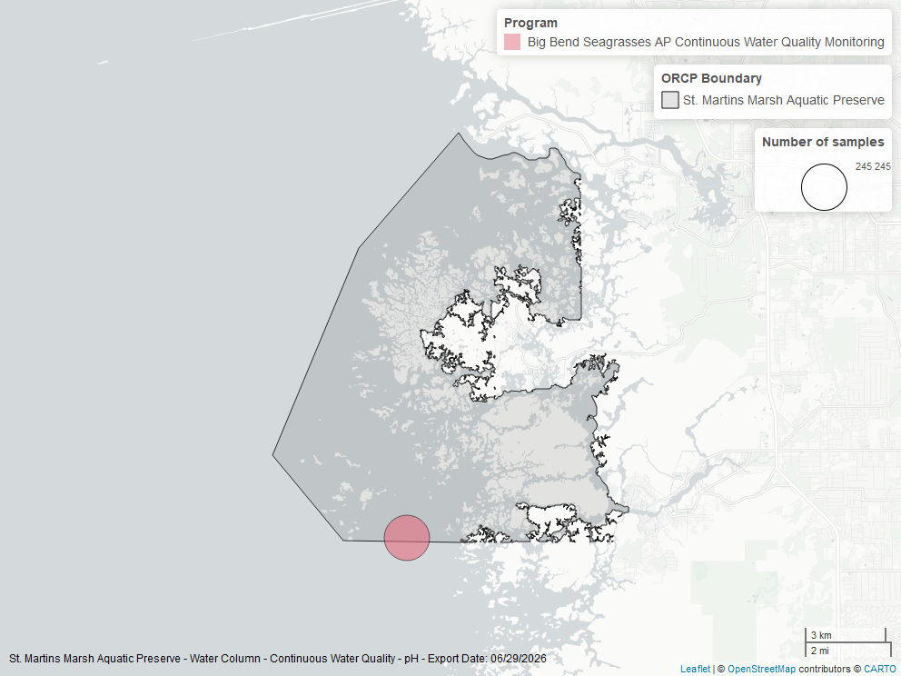

Map showing location of ph continuous water quality sampling locations within the boundaries of *St. Martins Marsh Aquatic Preserve*. The bubble size on the maps above reflect the amount of data available at each sampling site.

### pH - Discrete

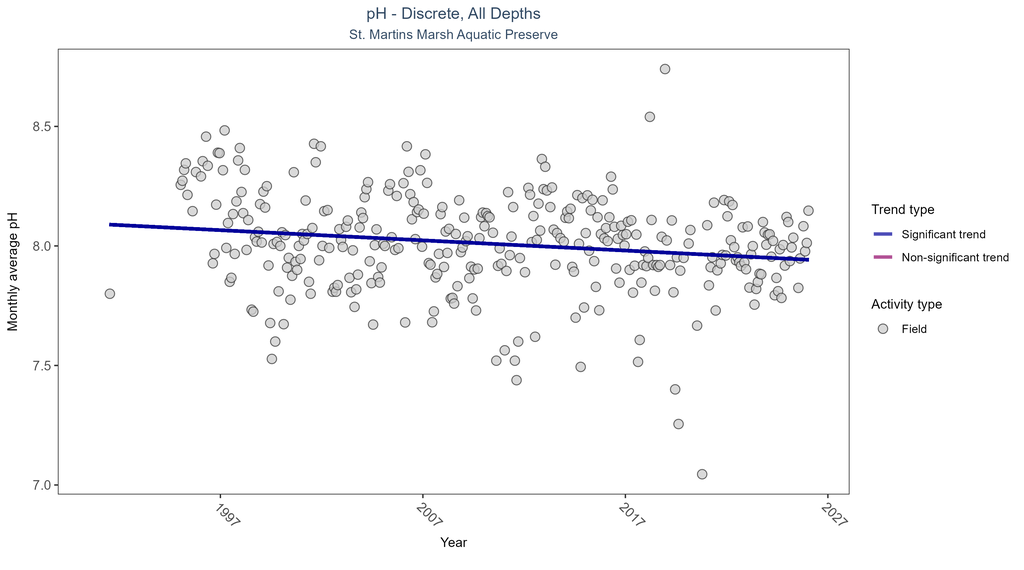

Scatter plot of monthly average pH over time. If the time series included ten or more years of discrete observations, a significant (blue) or non-significant (magenta) trend line is also shown. Only pH values measured in the field (circles) are included in the plot.

Table:

Monthly average pH decreased by less than 0.01 pH units per year.

| Activity Type | Statistical Trend | Sample Count | Years with Data | Period of Record | Median Result Value | Tau | Sen Intercept | Sen Slope | P |
| --- | --- | --- | --- | --- | --- | --- | --- | --- | --- |
| Field | Decreasing trend | 4826 | 33 | 1991 - 2026 | 8.06 | -0.14736 | 8.0915 | -0.00426 | 0.0002 |

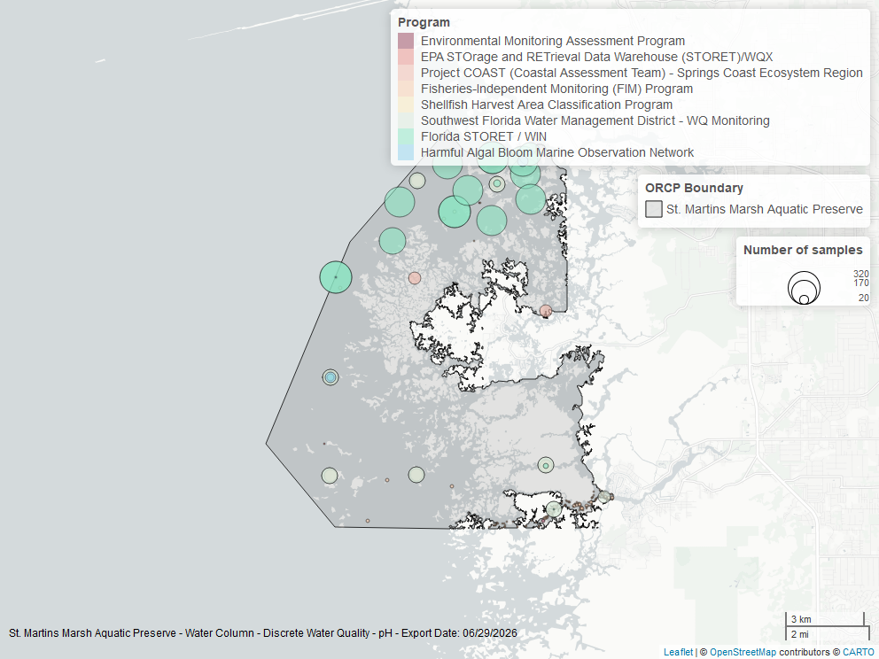

Map showing location of discrete water quality sampling locations within the boundaries of *St. Martins Marsh Aquatic Preserve*. The bubble size on the maps above reflect the amount of data available at each sampling site.

### Specific Conductivity - Continuous

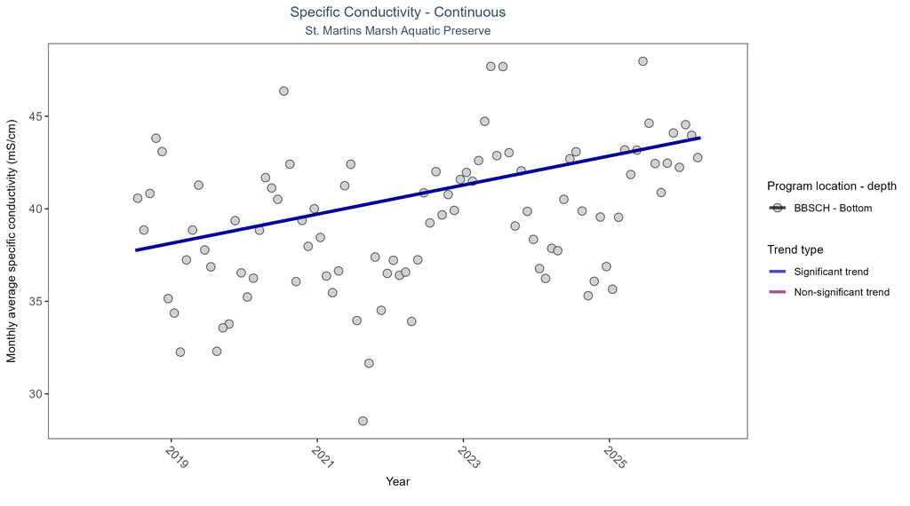

Scatter plot of monthly average specific conductivity over time at continuously monitored program locations. Each location is analyzed separately, with significant (blue) or non-significant (magenta) trend lines shown for time series that included five or more years of observations.

Table:

At one program location, monthly average specific conductivity increased by 0.79 mS/cm per year.

| Program Location | Statistical Trend | Sample Count | Years with Data | Period of Record | Median Result Value | Tau | Sen Intercept | Sen Slope | P |
| --- | --- | --- | --- | --- | --- | --- | --- | --- | --- |
| BBSCH | Increasing trend | 249935 | 9 | 2018 - 2026 | 39.91 | 0.35 | 37.35 | 0.79 | 0 |

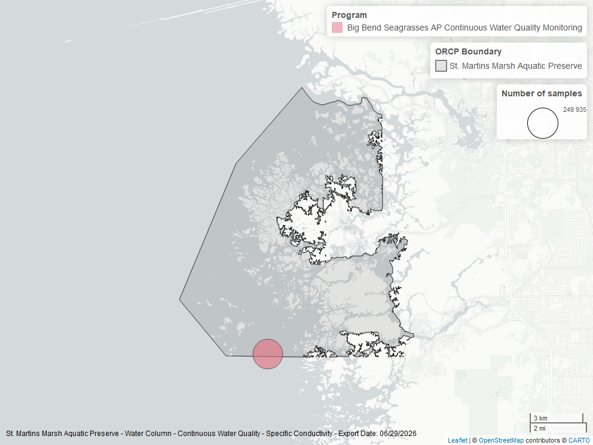

Map showing location of specific conductivity continuous water quality sampling locations within the boundaries of *St. Martins Marsh Aquatic Preserve*. The bubble size on the maps above reflect the amount of data available at each sampling site.

## Water Clarity

### Turbidity - Continuous

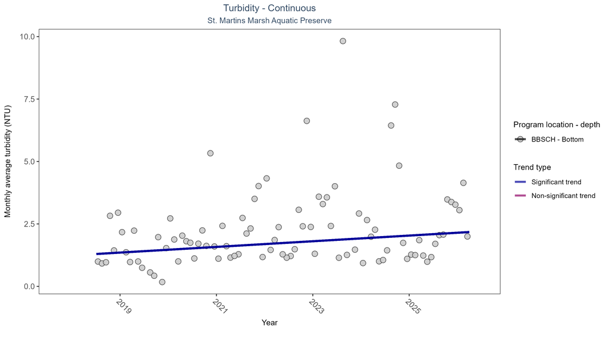

Scatter plot of monthly average turbidity over time at continuously monitored program locations. Each location is analyzed separately, with significant (blue) or non-significant (magenta) trend lines shown for time series that included five or more years of observations.

Table:

At one program location, monthly average turbidity increased by 0.11 NTU per year.

| Program Location | Statistical Trend | Sample Count | Years with Data | Period of Record | Median Result Value | Tau | Sen Intercept | Sen Slope | P |
| --- | --- | --- | --- | --- | --- | --- | --- | --- | --- |
| BBSCH | Increasing trend | 219010 | 9 | 2018 - 2026 | 1 | 0.25 | 1.24 | 0.11 | 0 |

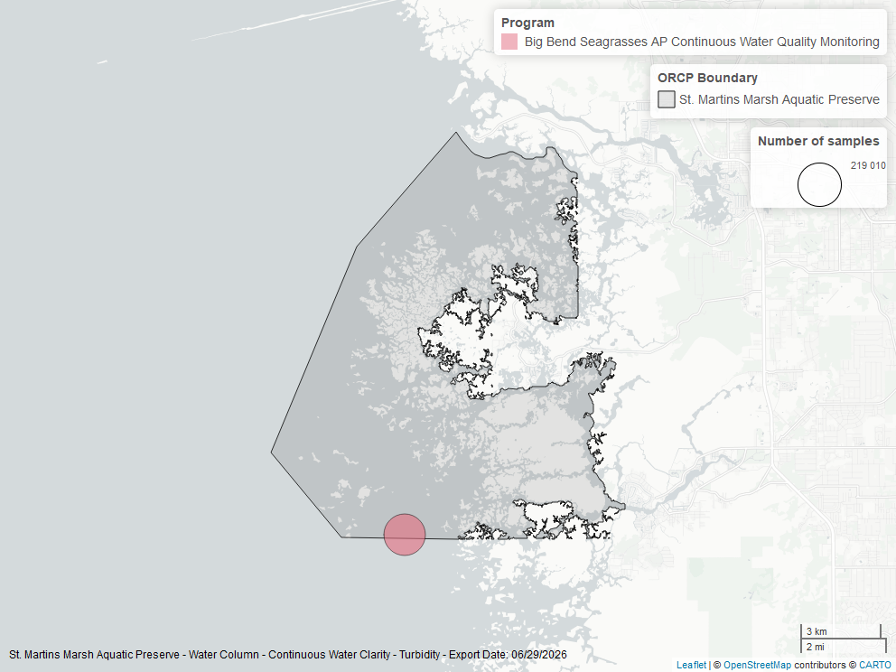

Map showing location of turbidity continuous water quality sampling locations within the boundaries of *St. Martins Marsh Aquatic Preserve*. The bubble size on the maps above reflect the amount of data available at each sampling site.

### Turbidity - Discrete

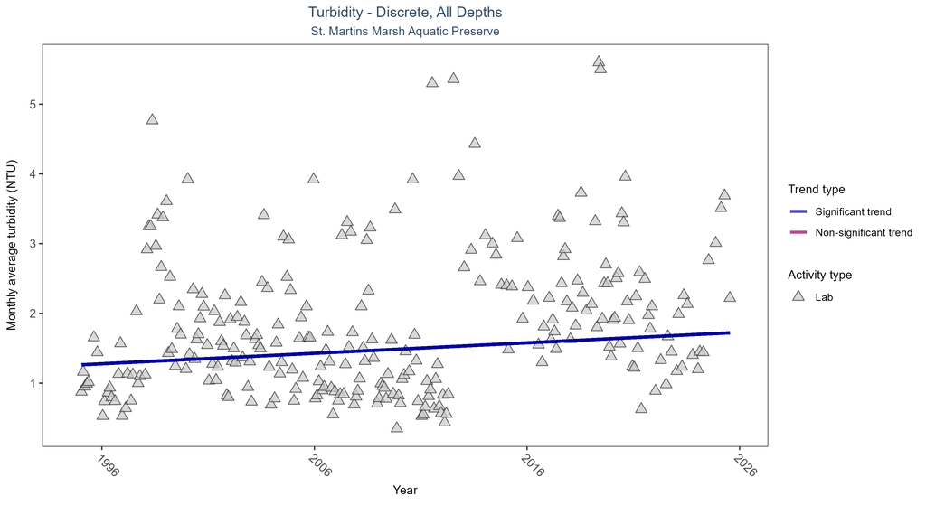

Scatter plot of monthly average turbidity over time. If the time series included ten or more years of discrete observations, a significant (blue) or non-significant (magenta) trend line is also shown. Only turbidity values measured in the laboratory (triangles) are included in the plot.

Table:

Monthly average turbidity increased by 0.02 NTU per year, indicating a decrease in water clarity.

| Activity Type | Statistical Trend | Sample Count | Years with Data | Period of Record | Median Result Value | Tau | Sen Intercept | Sen Slope | P |
| --- | --- | --- | --- | --- | --- | --- | --- | --- | --- |
| Lab | Increasing trend | 3158 | 31 | 1995 - 2025 | 1.1 | 0.11311 | 1.26251 | 0.01502 | 0.0121 |

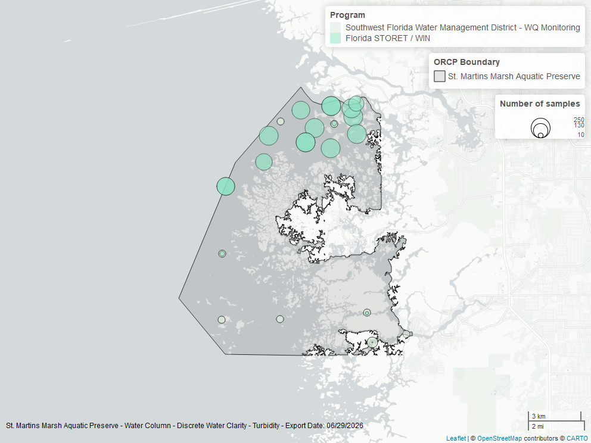

Map showing location of discrete water quality sampling locations within the boundaries of *St. Martins Marsh Aquatic Preserve*. The bubble size on the maps above reflect the amount of data available at each sampling site.

### Total Suspended Solids - Discrete

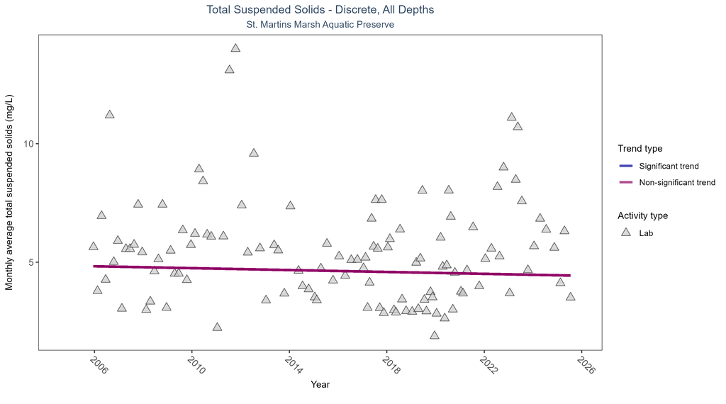

Scatter plot of monthly average total suspended solids (TSS) over time. If the time series included ten or more years of discrete observations, a significant (blue) or non-significant (magenta) trend line is also shown. Only TSS values obtained from laboratory analyses (triangles) are included in the plot.

Table:

Total suspended solids showed no detectable trend between 2005 and 2025.

| Activity Type | Statistical Trend | Sample Count | Years with Data | Period of Record | Median Result Value | Tau | Sen Intercept | Sen Slope | P |
| --- | --- | --- | --- | --- | --- | --- | --- | --- | --- |
| Lab | No detectable trend | 330 | 21 | 2005 - 2025 | 4.64 | 0.00139 | 4.84802 | -0.02 | 0.7079 |

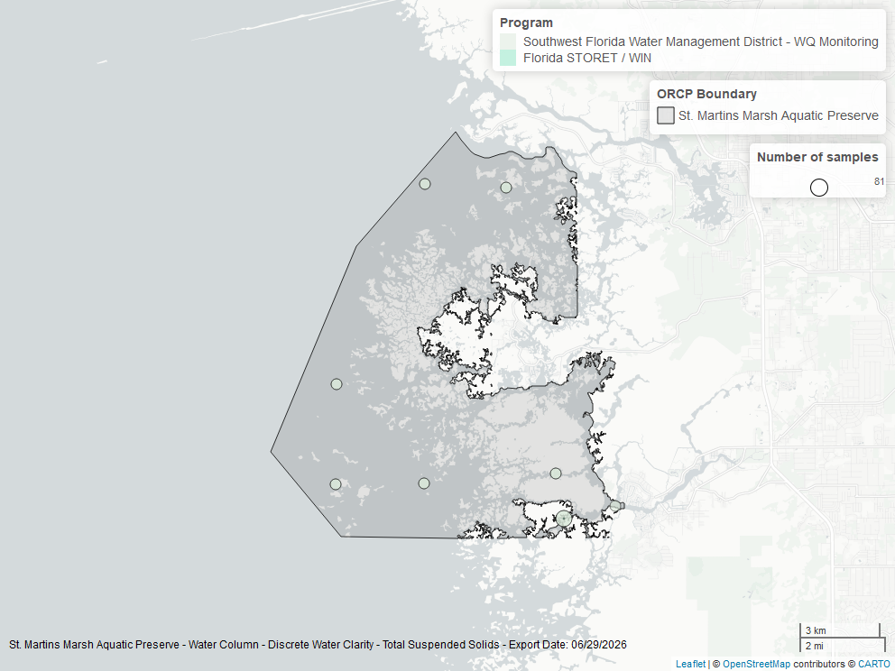

Map showing location of discrete water quality sampling locations within the boundaries of *St. Martins Marsh Aquatic Preserve*. The bubble size on the maps above reflect the amount of data available at each sampling site.